# Resampling Methods

## Resampling

Def: *Draw many samples from the training data and refit the model to each in order to learn about your model.*

## Cross-Validation

## Cross-Validation

Methods to estimate the test error rate (MSE, misclassification error) by

- holding out a subset of othe training data from the fitting process
- using that model to predict on the subset

### Three Flavors

1. Validation Set
2. Leave-one-out
3. \(k\)-fold

## Validation Set

1. Randomly split data into a *training set* and a *validation set*.
2. Fit model to *training set*.
3. Use model to predict responses for *validation set*.
4. Compute validation set error rate as estimate of test error rate.

Let's look back on how we compared Logistic Regression to LDA . . .

## Split data into training/validation

```r
library(ISLR)
data(Default)
set.seed(39)
test_ind <- sample(1:10000, size = 5000)
Default_test <- Default[test_ind, ]
Default_train <- Default[-test_ind, ]
```

## Fit models to train

```r
m1 <- glm(default ~ balance, data = Default_train, family = binomial)

library(dplyr)
est <- Default_train %>%
  group_by(default) %>%
  summarize(n = n(),
            prop = n/nrow(Default_train),
            mu = mean(balance),
            ssx = var(balance) * (n - 1))
```

## Fit models to train

Pull off estimates (and convert class).

```r
pi_n <- as.numeric(est[1, 3])
pi_y <- as.numeric(est[2, 3])
mu_n <- as.numeric(est[1, 4])
mu_y <- as.numeric(est[2, 4])
sig_sq <- (1/(nrow(Default_train) - 2)) * sum(est$ssx)
```

## Make predictions on validation

```r
log_pred <- predict(m1, newdata = Default_test, type = "response")

my_lda <- function(x, pi, mu, sig_sq) {
  x * (mu/sig_sq) - (mu^2)/(2 * sig_sq) + log(pi)
}
d_n <- my_lda(Default_test$balance, pi_n, mu_n, sig_sq)
d_y <- my_lda(Default_test$balance, pi_y, mu_y, sig_sq)

my_log_pred <- ifelse(log_pred < 0.5, "No", "Yes")
my_lda_pred <- ifelse(d_n > d_y, "No", "Yes")
```

## Misclassification Rates

```r
conf_log <- table(my_log_pred, Default_test$default)
conf_lda <- table(my_lda_pred, Default_test$default)
(1/nrow(Default_test)) * (conf_log[2, 1] + conf_log[1, 2])
```

```
## [1] 0.0266
```

```r
(1/nrow(Default_test)) * (conf_lda[2, 1] + conf_lda[1, 2])
```

```
## [1] 0.0258
```

**LDA has the lower test error rate**.

## Let's do that again

How would have our conclusions changed if we had used a different partition into training and validation sets?

```r
test_ind <- sample(1:10000, size = 5000)
Default_test <- Default[test_ind, ]
Default_train <- Default[-test_ind, ]
```

(Re-run all that code)

```r
(1/nrow(Default_test)) * (conf_log[2, 1] + conf_log[1, 2])
```

```
## [1] 0.0294
```

```r
(1/nrow(Default_test)) * (conf_lda[2, 1] + conf_lda[1, 2])
```

```
## [1] 0.0296
```

## Let's do that many times

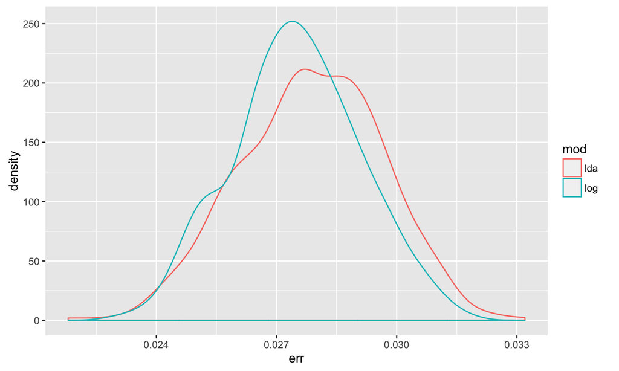

## Validation Set

### Downsides

1. Estimate of test error rate can be highly variable based on the partition.
2. You only use a fraction of the data to fit the model > overestimating test error rate.